# Loading and understanding the healthCaseData

# Assumption :-

1. Any variable having unique values less than 100 will be considered Categorical for first cut # Discard not required columns

```r
head(healthCaseData)
```

```
##        ID   IV   A1 A2   A3 A4    A5    A6    A7    A8    A9   A10 A11
## 1 1443894 2049   44  8   11  0     0     0     0    38   123   230  27
## 2 1810849   48    0  8    0  0     0     0     0     1     1     1  27
## 3 2264999  318    2  9    0  0     0     0     0     0     1     2  27
## 4 1931676   62    4  2    0  0     0    15    30     7    24    42  27
## 5 2070885    2    0  8    0  0     0     0     1     0     0     2  27
## 6 1566137 6648 2327  6 1404  0 11604 23532 35880 10516 25726 52263  27
##     A12 A13 A14  A15  A16 A17 A18 A19 A20      A21 A22 Target
## 1   330   0   0 0.52 0.69   0   0   0   1 17.07897   0      0
## 2     1   0   0 0.59 0.78   1   0   0   1 17.02238   0      0
## 3     2   0   0 0.94 0.79   1   0   0   0 17.02477   0      0
## 4    71   0   0 0.51 0.47   0   0   0   1 17.07500   0      0
## 5     2   0   0 0.82 0.81   0   0   0   1 17.07270   0      0
## 6 87824   0   0 0.74 0.50   0   0   0   1 17.07362   0      0
```

```r
healthCaseDataWithoutDisCol = subset(healthCaseData, select = - c(ID, A11))
head(healthCaseDataWithoutDisCol)
```

```
##     IV   A1 A2   A3 A4    A5    A6    A7    A8    A9   A10   A12 A13 A14
## 1 2049   44  8   11  0     0     0     0    38   123   230   330   0   0
## 2   48    0  8    0  0     0     0     0     1     1     1     1   0   0
## 3  318    2  9    0  0     0     0     0     0     1     2     2   0   0
## 4   62    4  2    0  0     0    15    30     7    24    42    71   0   0
## 5    2    0  8    0  0     0     0     1     0     0     2     2   0   0
## 6 6648 2327  6 1404  0 11604 23532 35880 10516 25726 52263 87824   0   0
##    A15  A16 A17 A18 A19 A20      A21 A22 Target
## 1 0.52 0.69   0   0   0   1 17.07897   0      0
## 2 0.59 0.78   1   0   0   1 17.02238   0      0
## 3 0.94 0.79   1   0   0   0 17.02477   0      0
## 4 0.51 0.47   0   0   0   1 17.07500   0      0
## 5 0.82 0.81   0   0   0   1 17.07270   0      0
## 6 0.74 0.50   0   0   0   1 17.07362   0      0
```

```r
# Define continuous & Categorical Columns
continuousColumn = c('IV', 'A1', 'A2', 'A3', 'A4', 'A5', 'A6', 'A7', 'A8', 'A9', 'A10', 'A12', 'A14', 'A15', 'A16', 'A21')
continuousColumn
```

```
##  [1] "IV"  "A1"  "A2"  "A3"  "A4"  "A5"  "A6"  "A7"  "A8"  "A9"  "A10"
## [12] "A12" "A14" "A15" "A16" "A21"
```

```r
catColumn = setdiff(names(healthCaseDataWithoutDisCol), continuousColumn)
catColumn
```

```
## [1] "A13"    "A17"    "A18"    "A19"    "A20"    "A22"    "Target"
```

```r
# Datatype conversion
str(healthCaseDataWithoutDisCol)
```

```
## 'data.frame':    34281 obs. of  23 variables:
##  $ IV    : int  2049 48 318 62 2 6648 10 22 160 8 ...
##  $ A1    : int  44 0 2 4 0 2327 3 0 43 0 ...
##  $ A2    : int  8 8 9 2 8 6 8 8 8 12 ...
##  $ A3    : int  11 0 0 0 0 1404 0 1 13 0 ...
##  $ A4    : int  0 0 0 0 0 0 0 0 0 0 ...
##  $ A5    : int  0 0 0 0 0 11604 3 0 0 0 ...
##  $ A6    : int  0 0 0 15 0 23532 12 0 120 0 ...
##  $ A7    : int  0 0 0 30 1 35880 21 3 180 0 ...
##  $ A8    : int  38 1 0 7 0 10516 3 5 15 0 ...
##  $ A9    : int  123 1 1 24 0 25726 13 13 59 0 ...
##  $ A10   : int  230 1 2 42 2 52263 20 34 150 0 ...
##  $ A12   : int  330 1 2 71 2 87824 33 51 238 0 ...
##  $ A13   : int  0 0 0 0 0 0 0 0 0 0 ...
##  $ A14   : int  0 0 0 0 0 0 0 0 0 0 ...
##  $ A15   : num  0.52 0.59 0.94 0.51 0.82 0.74 0.98 0.99 1 0.74 ...
##  $ A16   : num  0.69 0.78 0.79 0.47 0.81 0.5 0.98 0.99 1 0.74 ...
##  $ A17   : int  0 1 1 0 0 0 0 0 0 0 ...
##  $ A18   : int  0 0 0 0 0 0 0 0 0 0 ...
##  $ A19   : int  0 0 0 0 0 0 0 0 0 0 ...
##  $ A20   : int  1 1 0 1 1 1 1 1 1 1 ...
##  $ A21   : num  17.1 17 17 17.1 17.1 ...
##  $ A22   : int  0 0 0 0 0 0 0 0 0 0 ...
##  $ Target: int  0 0 0 0 0 0 0 0 0 0 ...
```

```r
catColumnConverted = sapply(healthCaseDataWithoutDisCol[catColumn], function(x) as.factor(x))
str(catColumnConverted)
```

```
##  chr [1:34281, 1:7] "0" "0" "0" "0" "0" "0" "0" "0" "0" "0" "0" "0" ...
##  - attr(*, "dimnames")=List of 2
##   ..$ : NULL
##   ..$ : chr [1:7] "A13" "A17" "A18" "A19" ...
```

```r
summary(catColumnConverted)
```

```
##  A13       A17       A18       A19       A20       A22       Target
##  0:34218   0:27128   0:34270   0:29758   0: 1290   0:34274   0:22988
##  1:   63   1: 7153   1:   11   1: 4523   1:32991   1:    7   1:11293
```

```r
head(catColumnConverted)
```

```
##      A13 A17 A18 A19 A20 A22 Target
## [1,] "0" "0" "0" "0" "1" "0" "0"
## [2,] "0" "1" "0" "0" "1" "0" "0"
## [3,] "0" "1" "0" "0" "0" "0" "0"
## [4,] "0" "0" "0" "0" "1" "0" "0"
## [5,] "0" "0" "0" "0" "1" "0" "0"
## [6,] "0" "0" "0" "0" "1" "0" "0"
```

```r
"
contColumnConverted = sapply(healthCaseDataWithoutDisCol[continuousColumn], function(x) as.numeric(x))
str(contColumnConverted)
summary(contColumnConverted)
head(contColumnConverted)
# Merge the categorical & continuous Column
healthCaseDataTypeAlt = cbind(catColumnConverted, contColumnConverted)
"
```

[output not shown]

```r
# Merge the categorical & continuous Column
healthCaseDataTypeAlt = cbind(catColumnConverted, healthCaseDataWithoutDisCol[continuousColumn])


str(healthCaseDataTypeAlt)
```

```
## 'data.frame':    34281 obs. of  23 variables:
##  $ A13   : Factor w/ 2 levels "0","1": 1 1 1 1 1 1 1 1 1 1 ...
##  $ A17   : Factor w/ 2 levels "0","1": 1 2 2 1 1 1 1 1 1 1 ...
##  $ A18   : Factor w/ 2 levels "0","1": 1 1 1 1 1 1 1 1 1 1 ...
##  $ A19   : Factor w/ 2 levels "0","1": 1 1 1 1 1 1 1 1 1 1 ...
##  $ A20   : Factor w/ 2 levels "0","1": 2 2 1 2 2 2 2 2 2 2 ...
##  $ A22   : Factor w/ 2 levels "0","1": 1 1 1 1 1 1 1 1 1 1 ...
##  $ Target: Factor w/ 2 levels "0","1": 1 1 1 1 1 1 1 1 1 1 ...
##  $ IV    : int  2049 48 318 62 2 6648 10 22 160 8 ...
##  $ A1    : int  44 0 2 4 0 2327 3 0 43 0 ...
##  $ A2    : int  8 8 9 2 8 6 8 8 8 12 ...
##  $ A3    : int  11 0 0 0 0 1404 0 1 13 0 ...
##  $ A4    : int  0 0 0 0 0 0 0 0 0 0 ...
##  $ A5    : int  0 0 0 0 0 11604 3 0 0 0 ...
##  $ A6    : int  0 0 0 15 0 23532 12 0 120 0 ...
##  $ A7    : int  0 0 0 30 1 35880 21 3 180 0 ...
##  $ A8    : int  38 1 0 7 0 10516 3 5 15 0 ...
##  $ A9    : int  123 1 1 24 0 25726 13 13 59 0 ...
##  $ A10   : int  230 1 2 42 2 52263 20 34 150 0 ...
##  $ A12   : int  330 1 2 71 2 87824 33 51 238 0 ...
##  $ A14   : int  0 0 0 0 0 0 0 0 0 0 ...
##  $ A15   : num  0.52 0.59 0.94 0.51 0.82 0.74 0.98 0.99 1 0.74 ...
##  $ A16   : num  0.69 0.78 0.79 0.47 0.81 0.5 0.98 0.99 1 0.74 ...
##  $ A21   : num  17.1 17 17 17.1 17.1 ...
```

```r
summary(healthCaseDataTypeAlt)
```

```
##  A13       A17       A18       A19       A20       A22       Target
##  0:34218   0:27128   0:34270   0:29758   0: 1290   0:34274   0:22988
##  1:   63   1: 7153   1:   11   1: 4523   1:32991   1:    7   1:11293
##
##
##
##
##
##        IV                 A1                 A2               A3
##  Min.   : -2999.0   Min.   :    0.00   Min.   : 0.000   Min.   :    0.00
##  1st Qu.:     2.0   1st Qu.:    0.00   1st Qu.: 2.000   1st Qu.:    0.00
##  Median :     8.0   Median :    0.00   Median : 8.000   Median :    0.00
##  Mean   :   236.3   Mean   :   36.13   Mean   : 7.355   Mean   :   22.54
##  3rd Qu.:    40.0   3rd Qu.:    4.00   3rd Qu.: 8.000   3rd Qu.:    0.00
##  Max.   :366924.0   Max.   :50547.00   Max.   :52.000   Max.   :31750.00
##                                        NA's   :1743
##        A4                 A5               A6                 A7
##  Min.   :   0.000   Min.   :     0   Min.   :     0.0   Min.   :     0.0
##  1st Qu.:   0.000   1st Qu.:     0   1st Qu.:     0.0   1st Qu.:     0.0
##  Median :   0.000   Median :     0   Median :     2.0   Median :     4.0
##  Mean   :   1.695   Mean   :   152   Mean   :   274.4   Mean   :   387.9
##  3rd Qu.:   0.000   3rd Qu.:    18   3rd Qu.:    33.0   3rd Qu.:    48.0
##  Max.   :2999.000   Max.   :260660   Max.   :438020.0   Max.   :533540.0
##
##        A8                 A9                A10
##  Min.   :    0.00   Min.   :     0.0   Min.   :     0.0
##  1st Qu.:    0.00   1st Qu.:     0.0   1st Qu.:     0.0
##  Median :    1.00   Median :     3.0   Median :     6.0
##  Mean   :   36.48   Mean   :   132.9   Mean   :   236.6
##  3rd Qu.:    6.00   3rd Qu.:    19.0   3rd Qu.:    37.0
##  Max.   :21071.00   Max.   :742110.0   Max.   :742750.0
##
##       A12                A14                A15             A16
##  Min.   :     0.0   Min.   :   0.000   Min.   :0.000   Min.   :0.0000
##  1st Qu.:     0.0   1st Qu.:   0.000   1st Qu.:0.670   1st Qu.:0.6600
##  Median :     8.0   Median :   0.000   Median :0.830   Median :0.8200
##  Mean   :   341.2   Mean   :   1.745   Mean   :0.755   Mean   :0.7505
##  3rd Qu.:    54.0   3rd Qu.:   0.000   3rd Qu.:0.970   3rd Qu.:0.9500
##  Max.   :743215.0   Max.   :1488.000   Max.   :1.000   Max.   :1.0000
##                                        NA's   :2233    NA's   :2103
##       A21
##  Min.   :17.00
##  1st Qu.:17.02
##  Median :17.05
##  Mean   :17.05
##  3rd Qu.:17.07
##  Max.   :17.10
##
```

```r
head(healthCaseDataTypeAlt)
```

```
##   A13 A17 A18 A19 A20 A22 Target   IV   A1 A2   A3 A4    A5    A6    A7
## 1   0   0   0   0   1   0      0 2049   44  8   11  0     0     0     0
## 2   0   1   0   0   1   0      0   48    0  8    0  0     0     0     0
## 3   0   1   0   0   0   0      0  318    2  9    0  0     0     0     0
## 4   0   0   0   0   1   0      0   62    4  2    0  0     0    15    30
## 5   0   0   0   0   1   0      0    2    0  8    0  0     0     0     1
## 6   0   0   0   0   1   0      0 6648 2327  6 1404  0 11604 23532 35880
##      A8    A9   A10   A12 A14  A15  A16      A21
## 1    38   123   230   330   0 0.52 0.69 17.07897
## 2     1     1     1     1   0 0.59 0.78 17.02238
## 3     0     1     2     2   0 0.94 0.79 17.02477
## 4     7    24    42    71   0 0.51 0.47 17.07500
## 5     0     0     2     2   0 0.82 0.81 17.07270
## 6 10516 25726 52263 87824   0 0.74 0.50 17.07362
```

```r
"
Observations:-
1. A13, A18 & A22 are highly imbalanced. So will not contribute to prediction much, hence can be dropped.
"
```

```
## [1] "\nObservations:-\n1. A13, A18 & A22 are highly imbalanced. So will not contribute to prediction much, hence can be dropped.\n"
```

```r
healthCaseDataRefined = subset(healthCaseDataTypeAlt, select = - c(A13, A18, A22))
str(healthCaseDataRefined)
```

```
## 'data.frame':    34281 obs. of  20 variables:
##  $ A17   : Factor w/ 2 levels "0","1": 1 2 2 1 1 1 1 1 1 1 ...
##  $ A19   : Factor w/ 2 levels "0","1": 1 1 1 1 1 1 1 1 1 1 ...
##  $ A20   : Factor w/ 2 levels "0","1": 2 2 1 2 2 2 2 2 2 2 ...
##  $ Target: Factor w/ 2 levels "0","1": 1 1 1 1 1 1 1 1 1 1 ...
##  $ IV    : int  2049 48 318 62 2 6648 10 22 160 8 ...
##  $ A1    : int  44 0 2 4 0 2327 3 0 43 0 ...
##  $ A2    : int  8 8 9 2 8 6 8 8 8 12 ...
##  $ A3    : int  11 0 0 0 0 1404 0 1 13 0 ...
##  $ A4    : int  0 0 0 0 0 0 0 0 0 0 ...
##  $ A5    : int  0 0 0 0 0 11604 3 0 0 0 ...
##  $ A6    : int  0 0 0 15 0 23532 12 0 120 0 ...
##  $ A7    : int  0 0 0 30 1 35880 21 3 180 0 ...
##  $ A8    : int  38 1 0 7 0 10516 3 5 15 0 ...
##  $ A9    : int  123 1 1 24 0 25726 13 13 59 0 ...
##  $ A10   : int  230 1 2 42 2 52263 20 34 150 0 ...
##  $ A12   : int  330 1 2 71 2 87824 33 51 238 0 ...
##  $ A14   : int  0 0 0 0 0 0 0 0 0 0 ...
##  $ A15   : num  0.52 0.59 0.94 0.51 0.82 0.74 0.98 0.99 1 0.74 ...
##  $ A16   : num  0.69 0.78 0.79 0.47 0.81 0.5 0.98 0.99 1 0.74 ...
##  $ A21   : num  17.1 17 17 17.1 17.1 ...
```

```r
summary(healthCaseDataRefined)
```

```
##  A17       A19       A20       Target          IV
##  0:27128   0:29758   0: 1290   0:22988   Min.   : -2999.0
##  1: 7153   1: 4523   1:32991   1:11293   1st Qu.:     2.0
##                                          Median :     8.0
##                                          Mean   :   236.3
##                                          3rd Qu.:    40.0
##                                          Max.   :366924.0
##
##        A1                 A2               A3                 A4
##  Min.   :    0.00   Min.   : 0.000   Min.   :    0.00   Min.   :   0.000
##  1st Qu.:    0.00   1st Qu.: 2.000   1st Qu.:    0.00   1st Qu.:   0.000
##  Median :    0.00   Median : 8.000   Median :    0.00   Median :   0.000
##  Mean   :   36.13   Mean   : 7.355   Mean   :   22.54   Mean   :   1.695
##  3rd Qu.:    4.00   3rd Qu.: 8.000   3rd Qu.:    0.00   3rd Qu.:   0.000
##  Max.   :50547.00   Max.   :52.000   Max.   :31750.00   Max.   :2999.000
##                     NA's   :1743
##        A5               A6                 A7                 A8
##  Min.   :     0   Min.   :     0.0   Min.   :     0.0   Min.   :    0.00
##  1st Qu.:     0   1st Qu.:     0.0   1st Qu.:     0.0   1st Qu.:    0.00
##  Median :     0   Median :     2.0   Median :     4.0   Median :    1.00
##  Mean   :   152   Mean   :   274.4   Mean   :   387.9   Mean   :   36.48
##  3rd Qu.:    18   3rd Qu.:    33.0   3rd Qu.:    48.0   3rd Qu.:    6.00
##  Max.   :260660   Max.   :438020.0   Max.   :533540.0   Max.   :21071.00
##
##        A9                A10                A12
##  Min.   :     0.0   Min.   :     0.0   Min.   :     0.0
##  1st Qu.:     0.0   1st Qu.:     0.0   1st Qu.:     0.0
##  Median :     3.0   Median :     6.0   Median :     8.0
##  Mean   :   132.9   Mean   :   236.6   Mean   :   341.2
##  3rd Qu.:    19.0   3rd Qu.:    37.0   3rd Qu.:    54.0
##  Max.   :742110.0   Max.   :742750.0   Max.   :743215.0
##
##       A14                A15             A16              A21
##  Min.   :   0.000   Min.   :0.000   Min.   :0.0000   Min.   :17.00
##  1st Qu.:   0.000   1st Qu.:0.670   1st Qu.:0.6600   1st Qu.:17.02
##  Median :   0.000   Median :0.830   Median :0.8200   Median :17.05
##  Mean   :   1.745   Mean   :0.755   Mean   :0.7505   Mean   :17.05
##  3rd Qu.:   0.000   3rd Qu.:0.970   3rd Qu.:0.9500   3rd Qu.:17.07
##  Max.   :1488.000   Max.   :1.000   Max.   :1.0000   Max.   :17.10
##                     NA's   :2233    NA's   :2103
```

```r
head(healthCaseDataRefined)
```

```
##   A17 A19 A20 Target   IV   A1 A2   A3 A4    A5    A6    A7    A8    A9
## 1   0   0   1      0 2049   44  8   11  0     0     0     0    38   123
## 2   1   0   1      0   48    0  8    0  0     0     0     0     1     1
## 3   1   0   0      0  318    2  9    0  0     0     0     0     0     1
## 4   0   0   1      0   62    4  2    0  0     0    15    30     7    24
## 5   0   0   1      0    2    0  8    0  0     0     0     1     0     0
## 6   0   0   1      0 6648 2327  6 1404  0 11604 23532 35880 10516 25726
##     A10   A12 A14  A15  A16      A21
## 1   230   330   0 0.52 0.69 17.07897
## 2     1     1   0 0.59 0.78 17.02238
## 3     2     2   0 0.94 0.79 17.02477
## 4    42    71   0 0.51 0.47 17.07500
## 5     2     2   0 0.82 0.81 17.07270
## 6 52263 87824   0 0.74 0.50 17.07362
```

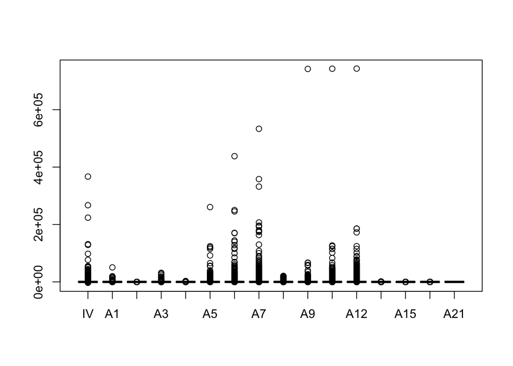

```r
# Remove outliers Based on continuous variables
boxplot(healthCaseDataRefined[continuousColumn], use.cols = TRUE)
```

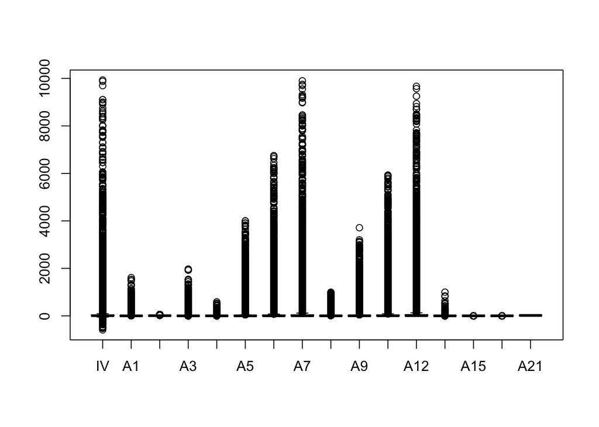

```r
#looking at attribute IV, A5, A6, A7, A9, A10, A12 have few above 10000, so we will remove those datpoints if they are fraction of total population
healthCaseDataFiltered = healthCaseDataRefined[(healthCaseDataRefined$IV <= 10000 & healthCaseDataRefined$A5 <= 4000 & healthCaseDataRefined$A6 <= 7000 &
                                                  healthCaseDataRefined$A7 <= 10000 & healthCaseDataRefined$A9 <= 4000 & healthCaseDataRefined$A10 <= 6000 &
                                                  healthCaseDataRefined$A12 <= 10000 & healthCaseDataRefined$A1 <= 2000 & healthCaseDataRefined$A3 <= 2000 &
                                                  healthCaseDataRefined$A4 <= 1000 & healthCaseDataRefined$A8 <= 1000 & healthCaseDataRefined$A14 <= 1000),]
boxplot(healthCaseDataFiltered[continuousColumn], use.cols = TRUE)
```

```r
cat("% of datapoints dropped : ", ((nrow(healthCaseData) -nrow(healthCaseDataFiltered))*100/nrow(healthCaseDataRefined)))
```

```
## % of datapoints dropped :  1.125988
```

```r
str(healthCaseDataFiltered)
```

```
## 'data.frame':    33895 obs. of  20 variables:
##  $ A17   : Factor w/ 2 levels "0","1": 1 2 2 1 1 1 1 1 1 1 ...
##  $ A19   : Factor w/ 2 levels "0","1": 1 1 1 1 1 1 1 1 1 1 ...
##  $ A20   : Factor w/ 2 levels "0","1": 2 2 1 2 2 2 2 2 2 2 ...
##  $ Target: Factor w/ 2 levels "0","1": 1 1 1 1 1 1 1 1 1 1 ...
##  $ IV    : int  2049 48 318 62 2 10 22 160 8 87 ...
##  $ A1    : int  44 0 2 4 0 3 0 43 0 2 ...
##  $ A2    : int  8 8 9 2 8 8 8 8 12 17 ...
##  $ A3    : int  11 0 0 0 0 0 1 13 0 0 ...
##  $ A4    : int  0 0 0 0 0 0 0 0 0 0 ...
##  $ A5    : int  0 0 0 0 0 3 0 0 0 0 ...
##  $ A6    : int  0 0 0 15 0 12 0 120 0 0 ...
##  $ A7    : int  0 0 0 30 1 21 3 180 0 29 ...
##  $ A8    : int  38 1 0 7 0 3 5 15 0 4 ...
##  $ A9    : int  123 1 1 24 0 13 13 59 0 8 ...
##  $ A10   : int  230 1 2 42 2 20 34 150 0 35 ...
##  $ A12   : int  330 1 2 71 2 33 51 238 0 58 ...
##  $ A14   : int  0 0 0 0 0 0 0 0 0 0 ...
##  $ A15   : num  0.52 0.59 0.94 0.51 0.82 0.98 0.99 1 0.74 0.26 ...
##  $ A16   : num  0.69 0.78 0.79 0.47 0.81 0.98 0.99 1 0.74 0.34 ...
##  $ A21   : num  17.1 17 17 17.1 17.1 ...
```

```r
summary(healthCaseDataFiltered)
```

```
##  A17       A19       A20       Target          IV
##  0:26773   0:29426   0: 1252   0:22697   Min.   :-591.0
##  1: 7122   1: 4469   1:32643   1:11198   1st Qu.:   2.0
##                                          Median :   8.0
##                                          Mean   : 112.4
##                                          3rd Qu.:  38.0
##                                          Max.   :9933.0
##
##        A1                A2               A3                 A4
##  Min.   :   0.00   Min.   : 0.000   Min.   :   0.000   Min.   :  0.0000
##  1st Qu.:   0.00   1st Qu.: 2.000   1st Qu.:   0.000   1st Qu.:  0.0000
##  Median :   0.00   Median : 8.000   Median :   0.000   Median :  0.0000
##  Mean   :  18.11   Mean   : 7.353   Mean   :   9.649   Mean   :  0.9845
##  3rd Qu.:   3.00   3rd Qu.: 8.000   3rd Qu.:   0.000   3rd Qu.:  0.0000
##  Max.   :1612.00   Max.   :52.000   Max.   :1971.000   Max.   :591.0000
##                    NA's   :1716
##        A5                A6               A7               A8
##  Min.   :   0.00   Min.   :   0.0   Min.   :   0.0   Min.   :  0.00
##  1st Qu.:   0.00   1st Qu.:   0.0   1st Qu.:   0.0   1st Qu.:  0.00
##  Median :   0.00   Median :   2.0   Median :   4.0   Median :  1.00
##  Mean   :  62.51   Mean   : 107.3   Mean   : 152.1   Mean   : 17.58
##  3rd Qu.:  18.00   3rd Qu.:  31.0   3rd Qu.:  46.0   3rd Qu.:  6.00
##  Max.   :4000.00   Max.   :6750.0   Max.   :9900.0   Max.   :998.00
##
##        A9               A10              A12              A14
##  Min.   :   0.00   Min.   :   0.0   Min.   :   0.0   Min.   :   0.000
##  1st Qu.:   0.00   1st Qu.:   0.0   1st Qu.:   0.0   1st Qu.:   0.000
##  Median :   3.00   Median :   5.0   Median :   8.0   Median :   0.000
##  Mean   :  54.46   Mean   : 103.6   Mean   : 155.3   Mean   :   1.151
##  3rd Qu.:  18.00   3rd Qu.:  35.0   3rd Qu.:  51.0   3rd Qu.:   0.000
##  Max.   :3712.00   Max.   :5930.0   Max.   :9669.0   Max.   :1000.000
##
##       A15              A16              A21
##  Min.   :0.0000   Min.   :0.0000   Min.   :17.00
##  1st Qu.:0.6700   1st Qu.:0.6600   1st Qu.:17.02
##  Median :0.8200   Median :0.8200   Median :17.05
##  Mean   :0.7545   Mean   :0.7501   Mean   :17.05
##  3rd Qu.:0.9600   3rd Qu.:0.9500   3rd Qu.:17.07
##  Max.   :1.0000   Max.   :1.0000   Max.   :17.10
##  NA's   :2191     NA's   :2065
```

```r
head(healthCaseDataFiltered)
```

```
##   A17 A19 A20 Target   IV A1 A2 A3 A4 A5 A6 A7 A8  A9 A10 A12 A14  A15
## 1   0   0   1      0 2049 44  8 11  0  0  0  0 38 123 230 330   0 0.52
## 2   1   0   1      0   48  0  8  0  0  0  0  0  1   1   1   1   0 0.59
## 3   1   0   0      0  318  2  9  0  0  0  0  0  0   1   2   2   0 0.94
## 4   0   0   1      0   62  4  2  0  0  0 15 30  7  24  42  71   0 0.51
## 5   0   0   1      0    2  0  8  0  0  0  0  1  0   0   2   2   0 0.82
## 7   0   0   1      0   10  3  8  0  0  3 12 21  3  13  20  33   0 0.98
##    A16      A21
## 1 0.69 17.07897
## 2 0.78 17.02238
## 3 0.79 17.02477
## 4 0.47 17.07500
## 5 0.81 17.07270
## 7 0.98 17.07850
```

# Dummyfication before Splitting to ensure we dont encounter scenario of unseen data for both test & train.

```r
library(caret)
healthCaseDataFilteredDummyFyModel = dummyVars(Target ~ ., data = healthCaseDataFiltered,fullRank = T)
healthCaseDataFilteredDummyfy = data.frame(predict(healthCaseDataFilteredDummyFyModel, newdata = healthCaseDataFiltered))
str(healthCaseDataFilteredDummyfy)
```

```
## 'data.frame':    33895 obs. of  19 variables:
##  $ A17.1: num  0 1 1 0 0 0 0 0 0 0 ...
##  $ A19.1: num  0 0 0 0 0 0 0 0 0 0 ...
##  $ A20.1: num  1 1 0 1 1 1 1 1 1 1 ...
##  $ IV   : num  2049 48 318 62 2 ...
##  $ A1   : num  44 0 2 4 0 3 0 43 0 2 ...
##  $ A2   : num  8 8 9 2 8 8 8 8 12 17 ...
##  $ A3   : num  11 0 0 0 0 0 1 13 0 0 ...
##  $ A4   : num  0 0 0 0 0 0 0 0 0 0 ...
##  $ A5   : num  0 0 0 0 0 3 0 0 0 0 ...
##  $ A6   : num  0 0 0 15 0 12 0 120 0 0 ...
##  $ A7   : num  0 0 0 30 1 21 3 180 0 29 ...
##  $ A8   : num  38 1 0 7 0 3 5 15 0 4 ...
##  $ A9   : num  123 1 1 24 0 13 13 59 0 8 ...
##  $ A10  : num  230 1 2 42 2 20 34 150 0 35 ...
##  $ A12  : num  330 1 2 71 2 33 51 238 0 58 ...
##  $ A14  : num  0 0 0 0 0 0 0 0 0 0 ...
##  $ A15  : num  0.52 0.59 0.94 0.51 0.82 0.98 0.99 1 0.74 0.26 ...
##  $ A16  : num  0.69 0.78 0.79 0.47 0.81 0.98 0.99 1 0.74 0.34 ...
##  $ A21  : num  17.1 17 17 17.1 17.1 ...
```

```r
summary(healthCaseDataFilteredDummyfy)
```

```
##      A17.1            A19.1            A20.1              IV
##  Min.   :0.0000   Min.   :0.0000   Min.   :0.0000   Min.   :-591.0
##  1st Qu.:0.0000   1st Qu.:0.0000   1st Qu.:1.0000   1st Qu.:   2.0
##  Median :0.0000   Median :0.0000   Median :1.0000   Median :   8.0
##  Mean   :0.2101   Mean   :0.1318   Mean   :0.9631   Mean   : 112.4
##  3rd Qu.:0.0000   3rd Qu.:0.0000   3rd Qu.:1.0000   3rd Qu.:  38.0
##  Max.   :1.0000   Max.   :1.0000   Max.   :1.0000   Max.   :9933.0
##
##        A1                A2               A3                 A4
##  Min.   :   0.00   Min.   : 0.000   Min.   :   0.000   Min.   :  0.0000
##  1st Qu.:   0.00   1st Qu.: 2.000   1st Qu.:   0.000   1st Qu.:  0.0000
##  Median :   0.00   Median : 8.000   Median :   0.000   Median :  0.0000
##  Mean   :  18.11   Mean   : 7.353   Mean   :   9.649   Mean   :  0.9845
##  3rd Qu.:   3.00   3rd Qu.: 8.000   3rd Qu.:   0.000   3rd Qu.:  0.0000
##  Max.   :1612.00   Max.   :52.000   Max.   :1971.000   Max.   :591.0000
##                    NA's   :1716
##        A5                A6               A7               A8
##  Min.   :   0.00   Min.   :   0.0   Min.   :   0.0   Min.   :  0.00
##  1st Qu.:   0.00   1st Qu.:   0.0   1st Qu.:   0.0   1st Qu.:  0.00
##  Median :   0.00   Median :   2.0   Median :   4.0   Median :  1.00
##  Mean   :  62.51   Mean   : 107.3   Mean   : 152.1   Mean   : 17.58
##  3rd Qu.:  18.00   3rd Qu.:  31.0   3rd Qu.:  46.0   3rd Qu.:  6.00
##  Max.   :4000.00   Max.   :6750.0   Max.   :9900.0   Max.   :998.00
##
##        A9               A10              A12              A14
##  Min.   :   0.00   Min.   :   0.0   Min.   :   0.0   Min.   :   0.000
##  1st Qu.:   0.00   1st Qu.:   0.0   1st Qu.:   0.0   1st Qu.:   0.000
##  Median :   3.00   Median :   5.0   Median :   8.0   Median :   0.000
##  Mean   :  54.46   Mean   : 103.6   Mean   : 155.3   Mean   :   1.151
##  3rd Qu.:  18.00   3rd Qu.:  35.0   3rd Qu.:  51.0   3rd Qu.:   0.000
##  Max.   :3712.00   Max.   :5930.0   Max.   :9669.0   Max.   :1000.000
##
##       A15              A16              A21
##  Min.   :0.0000   Min.   :0.0000   Min.   :17.00
##  1st Qu.:0.6700   1st Qu.:0.6600   1st Qu.:17.02
##  Median :0.8200   Median :0.8200   Median :17.05
##  Mean   :0.7545   Mean   :0.7501   Mean   :17.05
##  3rd Qu.:0.9600   3rd Qu.:0.9500   3rd Qu.:17.07
##  Max.   :1.0000   Max.   :1.0000   Max.   :17.10
##  NA's   :2191     NA's   :2065
```

```r
head(healthCaseDataFilteredDummyfy)
```

```
##   A17.1 A19.1 A20.1   IV A1 A2 A3 A4 A5 A6 A7 A8  A9 A10 A12 A14  A15  A16
## 1     0     0     1 2049 44  8 11  0  0  0  0 38 123 230 330   0 0.52 0.69
## 2     1     0     1   48  0  8  0  0  0  0  0  1   1   1   1   0 0.59 0.78
## 3     1     0     0  318  2  9  0  0  0  0  0  0   1   2   2   0 0.94 0.79
## 4     0     0     1   62  4  2  0  0  0 15 30  7  24  42  71   0 0.51 0.47
## 5     0     0     1    2  0  8  0  0  0  0  1  0   0   2   2   0 0.82 0.81
## 7     0     0     1   10  3  8  0  0  3 12 21  3  13  20  33   0 0.98 0.98
##        A21
## 1 17.07897
## 2 17.02238
## 3 17.02477
## 4 17.07500
## 5 17.07270
## 7 17.07850
```

```r
dim(healthCaseDataFilteredDummyfy)
```

```
## [1] 33895    19
```

```r
healthCaseDataFilteredDummyfy_1 = cbind(healthCaseDataFilteredDummyfy, healthCaseDataFiltered$Target)
names(healthCaseDataFilteredDummyfy_1)[names(healthCaseDataFilteredDummyfy_1) == 'healthCaseDataFiltered$Target'] = 'Target'
str(healthCaseDataFilteredDummyfy_1)
```

```
## 'data.frame':    33895 obs. of  20 variables:
##  $ A17.1 : num  0 1 1 0 0 0 0 0 0 0 ...
##  $ A19.1 : num  0 0 0 0 0 0 0 0 0 0 ...
##  $ A20.1 : num  1 1 0 1 1 1 1 1 1 1 ...
##  $ IV    : num  2049 48 318 62 2 ...
##  $ A1    : num  44 0 2 4 0 3 0 43 0 2 ...
##  $ A2    : num  8 8 9 2 8 8 8 8 12 17 ...
##  $ A3    : num  11 0 0 0 0 0 1 13 0 0 ...
##  $ A4    : num  0 0 0 0 0 0 0 0 0 0 ...
##  $ A5    : num  0 0 0 0 0 3 0 0 0 0 ...
##  $ A6    : num  0 0 0 15 0 12 0 120 0 0 ...
##  $ A7    : num  0 0 0 30 1 21 3 180 0 29 ...
##  $ A8    : num  38 1 0 7 0 3 5 15 0 4 ...
##  $ A9    : num  123 1 1 24 0 13 13 59 0 8 ...
##  $ A10   : num  230 1 2 42 2 20 34 150 0 35 ...
##  $ A12   : num  330 1 2 71 2 33 51 238 0 58 ...
##  $ A14   : num  0 0 0 0 0 0 0 0 0 0 ...
##  $ A15   : num  0.52 0.59 0.94 0.51 0.82 0.98 0.99 1 0.74 0.26 ...
##  $ A16   : num  0.69 0.78 0.79 0.47 0.81 0.98 0.99 1 0.74 0.34 ...
##  $ A21   : num  17.1 17 17 17.1 17.1 ...
##  $ Target: Factor w/ 2 levels "0","1": 1 1 1 1 1 1 1 1 1 1 ...
```

```r
summary(healthCaseDataFilteredDummyfy_1)
```

```
##      A17.1            A19.1            A20.1              IV
##  Min.   :0.0000   Min.   :0.0000   Min.   :0.0000   Min.   :-591.0
##  1st Qu.:0.0000   1st Qu.:0.0000   1st Qu.:1.0000   1st Qu.:   2.0
##  Median :0.0000   Median :0.0000   Median :1.0000   Median :   8.0
##  Mean   :0.2101   Mean   :0.1318   Mean   :0.9631   Mean   : 112.4
##  3rd Qu.:0.0000   3rd Qu.:0.0000   3rd Qu.:1.0000   3rd Qu.:  38.0
##  Max.   :1.0000   Max.   :1.0000   Max.   :1.0000   Max.   :9933.0
##
##        A1                A2               A3                 A4
##  Min.   :   0.00   Min.   : 0.000   Min.   :   0.000   Min.   :  0.0000
##  1st Qu.:   0.00   1st Qu.: 2.000   1st Qu.:   0.000   1st Qu.:  0.0000
##  Median :   0.00   Median : 8.000   Median :   0.000   Median :  0.0000
##  Mean   :  18.11   Mean   : 7.353   Mean   :   9.649   Mean   :  0.9845
##  3rd Qu.:   3.00   3rd Qu.: 8.000   3rd Qu.:   0.000   3rd Qu.:  0.0000
##  Max.   :1612.00   Max.   :52.000   Max.   :1971.000   Max.   :591.0000
##                    NA's   :1716
##        A5                A6               A7               A8
##  Min.   :   0.00   Min.   :   0.0   Min.   :   0.0   Min.   :  0.00
##  1st Qu.:   0.00   1st Qu.:   0.0   1st Qu.:   0.0   1st Qu.:  0.00
##  Median :   0.00   Median :   2.0   Median :   4.0   Median :  1.00
##  Mean   :  62.51   Mean   : 107.3   Mean   : 152.1   Mean   : 17.58
##  3rd Qu.:  18.00   3rd Qu.:  31.0   3rd Qu.:  46.0   3rd Qu.:  6.00
##  Max.   :4000.00   Max.   :6750.0   Max.   :9900.0   Max.   :998.00
##
##        A9               A10              A12              A14
##  Min.   :   0.00   Min.   :   0.0   Min.   :   0.0   Min.   :   0.000
##  1st Qu.:   0.00   1st Qu.:   0.0   1st Qu.:   0.0   1st Qu.:   0.000
##  Median :   3.00   Median :   5.0   Median :   8.0   Median :   0.000
##  Mean   :  54.46   Mean   : 103.6   Mean   : 155.3   Mean   :   1.151
##  3rd Qu.:  18.00   3rd Qu.:  35.0   3rd Qu.:  51.0   3rd Qu.:   0.000
##  Max.   :3712.00   Max.   :5930.0   Max.   :9669.0   Max.   :1000.000
##
##       A15              A16              A21        Target
##  Min.   :0.0000   Min.   :0.0000   Min.   :17.00   0:22697
##  1st Qu.:0.6700   1st Qu.:0.6600   1st Qu.:17.02   1:11198
##  Median :0.8200   Median :0.8200   Median :17.05
##  Mean   :0.7545   Mean   :0.7501   Mean   :17.05
##  3rd Qu.:0.9600   3rd Qu.:0.9500   3rd Qu.:17.07
##  Max.   :1.0000   Max.   :1.0000   Max.   :17.10
##  NA's   :2191     NA's   :2065
```

```r
head(healthCaseDataFilteredDummyfy_1)
```

```
##   A17.1 A19.1 A20.1   IV A1 A2 A3 A4 A5 A6 A7 A8  A9 A10 A12 A14  A15  A16
## 1     0     0     1 2049 44  8 11  0  0  0  0 38 123 230 330   0 0.52 0.69
## 2     1     0     1   48  0  8  0  0  0  0  0  1   1   1   1   0 0.59 0.78
## 3     1     0     0  318  2  9  0  0  0  0  0  0   1   2   2   0 0.94 0.79
## 4     0     0     1   62  4  2  0  0  0 15 30  7  24  42  71   0 0.51 0.47
## 5     0     0     1    2  0  8  0  0  0  0  1  0   0   2   2   0 0.82 0.81
## 7     0     0     1   10  3  8  0  0  3 12 21  3  13  20  33   0 0.98 0.98
##        A21 Target
## 1 17.07897      0
## 2 17.02238      0
## 3 17.02477      0
## 4 17.07500      0
## 5 17.07270      0
## 7 17.07850      0
```

```r
dim(healthCaseDataFilteredDummyfy_1)
```

```
## [1] 33895    20
```

# Split te data into train, validation & test

```r
dim(healthCaseDataFilteredDummyfy_1)
```

```
## [1] 33895    20
```

```r
train_rows = createDataPartition(c(healthCaseDataFilteredDummyfy_1$Target), p = 0.7, list = F)
train_data = healthCaseDataFilteredDummyfy_1[train_rows,]
dim(train_data)
```

```
## [1] 23727    20
```

```r
table(train_data$Target)
```

```
##
##     0     1
## 15903  7824
```

```r
validation_data = healthCaseDataFilteredDummyfy_1[-train_rows,]
dim(validation_data)
```

```
## [1] 10168    20
```

```r
table(validation_data$Target)
```

```
##
##    0    1
## 6794 3374
```

# Pre-Processing of training data

```r
head(train_data)
```

```
##   A17.1 A19.1 A20.1   IV A1 A2 A3 A4 A5  A6  A7 A8  A9 A10 A12 A14  A15
## 1     0     0     1 2049 44  8 11  0  0   0   0 38 123 230 330   0 0.52
## 3     1     0     0  318  2  9  0  0  0   0   0  0   1   2   2   0 0.94
## 5     0     0     1    2  0  8  0  0  0   0   1  0   0   2   2   0 0.82
## 7     0     0     1   10  3  8  0  0  3  12  21  3  13  20  33   0 0.98
## 8     0     0     1   22  0  8  1  0  0   0   3  5  13  34  51   0 0.99
## 9     0     0     1  160 43  8 13  0  0 120 180 15  59 150 238   0 1.00
##    A16      A21 Target
## 1 0.69 17.07897      0
## 3 0.79 17.02477      0
## 5 0.81 17.07270      0
## 7 0.98 17.07850      0
## 8 0.99 17.09144      0
## 9 1.00 17.04956      0
```

```r
str(train_data)
```

```
## 'data.frame':    23727 obs. of  20 variables:
##  $ A17.1 : num  0 1 0 0 0 0 0 0 0 0 ...
##  $ A19.1 : num  0 0 0 0 0 0 0 0 0 1 ...
##  $ A20.1 : num  1 0 1 1 1 1 1 1 1 1 ...
##  $ IV    : num  2049 318 2 10 22 ...
##  $ A1    : num  44 2 0 3 0 43 0 2 64 19 ...
##  $ A2    : num  8 9 8 8 8 8 12 17 8 8 ...
##  $ A3    : num  11 0 0 0 1 13 0 0 1 0 ...
##  $ A4    : num  0 0 0 0 0 0 0 0 0 0 ...
##  $ A5    : num  0 0 0 3 0 0 0 0 1250 0 ...
##  $ A6    : num  0 0 0 12 0 120 0 0 1250 48 ...
##  $ A7    : num  0 0 1 21 3 180 0 29 1250 48 ...
##  $ A8    : num  38 0 0 3 5 15 0 4 4 7 ...
##  $ A9    : num  123 1 0 13 13 59 0 8 35 21 ...
##  $ A10   : num  230 2 2 20 34 150 0 35 153 55 ...
##  $ A12   : num  330 2 2 33 51 238 0 58 336 82 ...
##  $ A14   : num  0 0 0 0 0 0 0 0 0 0 ...
##  $ A15   : num  0.52 0.94 0.82 0.98 0.99 1 0.74 0.26 NA 0.53 ...
##  $ A16   : num  0.69 0.79 0.81 0.98 0.99 1 0.74 0.34 0 0.54 ...
##  $ A21   : num  17.1 17 17.1 17.1 17.1 ...
##  $ Target: Factor w/ 2 levels "0","1": 1 1 1 1 1 1 1 1 1 1 ...
```

# Handling missing values

Count number of missing values in each Column

```r
sapply(train_data, function(x) sum(is.na(x) | -99 == x))
```

```
##  A17.1  A19.1  A20.1     IV     A1     A2     A3     A4     A5     A6
##      0      0      0      0      0   1206      0      0      0      0
##     A7     A8     A9    A10    A12    A14    A15    A16    A21 Target
##      0      0      0      0      0      0   1532   1438      0      0
```

Observations:- 1. No missing values in Target, so no need to drop any row.

```r
library(DMwR)
train_data_Imputed = centralImputation(train_data)
sapply(train_data_Imputed, function(x) sum(is.na(x) | -99 == x))
```

```
##  A17.1  A19.1  A20.1     IV     A1     A2     A3     A4     A5     A6
##      0      0      0      0      0      0      0      0      0      0
##     A7     A8     A9    A10    A12    A14    A15    A16    A21 Target
##      0      0      0      0      0      0      0      0      0      0
```

```r
head(train_data_Imputed)
```

```
##   A17.1 A19.1 A20.1   IV A1 A2 A3 A4 A5  A6  A7 A8  A9 A10 A12 A14  A15
## 1     0     0     1 2049 44  8 11  0  0   0   0 38 123 230 330   0 0.52
## 3     1     0     0  318  2  9  0  0  0   0   0  0   1   2   2   0 0.94
## 5     0     0     1    2  0  8  0  0  0   0   1  0   0   2   2   0 0.82
## 7     0     0     1   10  3  8  0  0  3  12  21  3  13  20  33   0 0.98
## 8     0     0     1   22  0  8  1  0  0   0   3  5  13  34  51   0 0.99
## 9     0     0     1  160 43  8 13  0  0 120 180 15  59 150 238   0 1.00
##    A16      A21 Target
## 1 0.69 17.07897      0
## 3 0.79 17.02477      0
## 5 0.81 17.07270      0
## 7 0.98 17.07850      0
## 8 0.99 17.09144      0
## 9 1.00 17.04956      0
```

```r
str(train_data_Imputed)
```

```
## 'data.frame':    23727 obs. of  20 variables:
##  $ A17.1 : num  0 1 0 0 0 0 0 0 0 0 ...
##  $ A19.1 : num  0 0 0 0 0 0 0 0 0 1 ...
##  $ A20.1 : num  1 0 1 1 1 1 1 1 1 1 ...
##  $ IV    : num  2049 318 2 10 22 ...
##  $ A1    : num  44 2 0 3 0 43 0 2 64 19 ...
##  $ A2    : num  8 9 8 8 8 8 12 17 8 8 ...
##  $ A3    : num  11 0 0 0 1 13 0 0 1 0 ...
##  $ A4    : num  0 0 0 0 0 0 0 0 0 0 ...
##  $ A5    : num  0 0 0 3 0 0 0 0 1250 0 ...
##  $ A6    : num  0 0 0 12 0 120 0 0 1250 48 ...
##  $ A7    : num  0 0 1 21 3 180 0 29 1250 48 ...
##  $ A8    : num  38 0 0 3 5 15 0 4 4 7 ...
##  $ A9    : num  123 1 0 13 13 59 0 8 35 21 ...
##  $ A10   : num  230 2 2 20 34 150 0 35 153 55 ...
##  $ A12   : num  330 2 2 33 51 238 0 58 336 82 ...
##  $ A14   : num  0 0 0 0 0 0 0 0 0 0 ...
##  $ A15   : num  0.52 0.94 0.82 0.98 0.99 1 0.74 0.26 0.82 0.53 ...
##  $ A16   : num  0.69 0.79 0.81 0.98 0.99 1 0.74 0.34 0 0.54 ...
##  $ A21   : num  17.1 17 17.1 17.1 17.1 ...
##  $ Target: Factor w/ 2 levels "0","1": 1 1 1 1 1 1 1 1 1 1 ...
```

```r
summary(train_data_Imputed)
```

```
##      A17.1            A19.1            A20.1              IV
##  Min.   :0.0000   Min.   :0.0000   Min.   :0.0000   Min.   :-528.0
##  1st Qu.:0.0000   1st Qu.:0.0000   1st Qu.:1.0000   1st Qu.:   2.0
##  Median :0.0000   Median :0.0000   Median :1.0000   Median :   8.0
##  Mean   :0.2106   Mean   :0.1326   Mean   :0.9622   Mean   : 113.9
##  3rd Qu.:0.0000   3rd Qu.:0.0000   3rd Qu.:1.0000   3rd Qu.:  39.0
##  Max.   :1.0000   Max.   :1.0000   Max.   :1.0000   Max.   :9933.0
##        A1                A2               A3                 A4
##  Min.   :   0.00   Min.   : 0.000   Min.   :   0.000   Min.   :  0.0000
##  1st Qu.:   0.00   1st Qu.: 4.000   1st Qu.:   0.000   1st Qu.:  0.0000
##  Median :   0.00   Median : 8.000   Median :   0.000   Median :  0.0000
##  Mean   :  18.17   Mean   : 7.393   Mean   :   9.697   Mean   :  0.9841
##  3rd Qu.:   3.00   3rd Qu.: 8.000   3rd Qu.:   0.000   3rd Qu.:  0.0000
##  Max.   :1612.00   Max.   :52.000   Max.   :1928.000   Max.   :532.0000
##        A5               A6               A7               A8
##  Min.   :   0.0   Min.   :   0.0   Min.   :   0.0   Min.   :  0.00
##  1st Qu.:   0.0   1st Qu.:   0.0   1st Qu.:   0.0   1st Qu.:  0.00
##  Median :   0.0   Median :   2.0   Median :   4.0   Median :  1.00
##  Mean   :  63.5   Mean   : 108.1   Mean   : 153.2   Mean   : 17.63
##  3rd Qu.:  18.0   3rd Qu.:  31.0   3rd Qu.:  46.0   3rd Qu.:  6.00
##  Max.   :4000.0   Max.   :6750.0   Max.   :9900.0   Max.   :998.00
##        A9               A10              A12              A14
##  Min.   :   0.00   Min.   :   0.0   Min.   :   0.0   Min.   :   0.000
##  1st Qu.:   0.00   1st Qu.:   0.0   1st Qu.:   0.0   1st Qu.:   0.000
##  Median :   3.00   Median :   5.0   Median :   8.0   Median :   0.000
##  Mean   :  55.03   Mean   : 104.9   Mean   : 156.6   Mean   :   1.173
##  3rd Qu.:  18.00   3rd Qu.:  35.0   3rd Qu.:  51.0   3rd Qu.:   0.000
##  Max.   :3202.00   Max.   :5930.0   Max.   :9669.0   Max.   :1000.000
##       A15              A16              A21        Target
##  Min.   :0.0000   Min.   :0.0000   Min.   :17.00   0:15903
##  1st Qu.:0.6800   1st Qu.:0.6800   1st Qu.:17.02   1: 7824
##  Median :0.8200   Median :0.8100   Median :17.05
##  Mean   :0.7575   Mean   :0.7523   Mean   :17.05
##  3rd Qu.:0.9600   3rd Qu.:0.9400   3rd Qu.:17.07
##  Max.   :1.0000   Max.   :1.0000   Max.   :17.10
```

# Get Imputation values of each column

```r
imputedValues = sapply(train_data_Imputed[colnames(train_data_Imputed)], function(x) centralValue(unlist(x)))
typeof(imputedValues)
```

```
## [1] "character"
```

```r
length(imputedValues)
```

```
## [1] 20
```

```r
imputedValues
```

```
##         A17.1         A19.1         A20.1            IV            A1
##           "0"           "0"           "1"           "8"           "0"
##            A2            A3            A4            A5            A6
##           "8"           "0"           "0"           "0"           "2"
##            A7            A8            A9           A10           A12
##           "4"           "1"           "3"           "5"           "8"
##           A14           A15           A16           A21        Target
##           "0"        "0.82"        "0.81" "17.04958756"           "0"
```

# Standardize the Continuous variables for quick convergence

```r
library(caret)
std_model = preProcess(train_data_Imputed[, !names(train_data_Imputed) %in% c("Target")], method = c("center", "scale"))
std_model
```

```
## Created from 23727 samples and 19 variables
##
## Pre-processing:
##   - centered (19)
##   - ignored (0)
##   - scaled (19)
```

```r
train_data_Imputed_stand = predict(object = std_model,newdata = train_data_Imputed[, !names(train_data_Imputed) %in% c("Target")])
head(train_data_Imputed_stand)
```

```
##       A17.1      A19.1     A20.1          IV         A1        A2
## 1 -0.516442 -0.3910358  0.198099  3.77157266  0.3666650 0.1017770
## 3  1.936244 -0.3910358 -5.047767  0.39787947 -0.2295756 0.2693712
## 5 -0.516442 -0.3910358  0.198099 -0.21799982 -0.2579680 0.1017770
## 7 -0.516442 -0.3910358  0.198099 -0.20240794 -0.2153794 0.1017770
## 8 -0.516442 -0.3910358  0.198099 -0.17902012 -0.2579680 0.1017770
## 9 -0.516442 -0.3910358  0.198099  0.08993983  0.3524688 0.1017770
##            A3          A4         A5          A6         A7          A8
## 1  0.02134948 -0.08007735 -0.2535743 -0.25929558 -0.2580697  0.30508273
## 3 -0.15895565 -0.08007735 -0.2535743 -0.25929558 -0.2580697 -0.26406677
## 5 -0.15895565 -0.08007735 -0.2535743 -0.25929558 -0.2563848 -0.26406677
## 7 -0.15895565 -0.08007735 -0.2415946 -0.23052469 -0.2226873 -0.21913391
## 8 -0.14256428 -0.08007735 -0.2535743 -0.25929558 -0.2530151 -0.18917868
## 9  0.05413223 -0.08007735 -0.2535743  0.02841328  0.0452083 -0.03940249
##            A9        A10        A12         A14        A15        A16
## 1  0.32480250  0.3151191  0.2903552 -0.07945704 -0.9343976 -0.2533243
## 3 -0.25819843 -0.2592683 -0.2589895 -0.07945704  0.7183107  0.1531067
## 5 -0.26297712 -0.2592683 -0.2589895 -0.07945704  0.2461083  0.2343929
## 7 -0.20085407 -0.2139219 -0.2070697 -0.07945704  0.8757115  0.9253256
## 8 -0.20085407 -0.1786525 -0.1769227 -0.07945704  0.9150617  0.9659687
## 9  0.01896595  0.1135797  0.1362707 -0.07945704  0.9544119  1.0066118
##            A21
## 1  1.016101240
## 3 -0.862454257
## 5  0.798629931
## 7  0.999656475
## 8  1.448157947
## 9 -0.003240581
```

```r
train_data_Imputed_with_Stand = cbind(train_data_Imputed_stand, train_data_Imputed["Target"])
head(train_data_Imputed_with_Stand)
```

```
##       A17.1      A19.1     A20.1          IV         A1        A2
## 1 -0.516442 -0.3910358  0.198099  3.77157266  0.3666650 0.1017770
## 3  1.936244 -0.3910358 -5.047767  0.39787947 -0.2295756 0.2693712
## 5 -0.516442 -0.3910358  0.198099 -0.21799982 -0.2579680 0.1017770
## 7 -0.516442 -0.3910358  0.198099 -0.20240794 -0.2153794 0.1017770
## 8 -0.516442 -0.3910358  0.198099 -0.17902012 -0.2579680 0.1017770
## 9 -0.516442 -0.3910358  0.198099  0.08993983  0.3524688 0.1017770
##            A3          A4         A5          A6         A7          A8
## 1  0.02134948 -0.08007735 -0.2535743 -0.25929558 -0.2580697  0.30508273
## 3 -0.15895565 -0.08007735 -0.2535743 -0.25929558 -0.2580697 -0.26406677
## 5 -0.15895565 -0.08007735 -0.2535743 -0.25929558 -0.2563848 -0.26406677
## 7 -0.15895565 -0.08007735 -0.2415946 -0.23052469 -0.2226873 -0.21913391
## 8 -0.14256428 -0.08007735 -0.2535743 -0.25929558 -0.2530151 -0.18917868
## 9  0.05413223 -0.08007735 -0.2535743  0.02841328  0.0452083 -0.03940249
##            A9        A10        A12         A14        A15        A16
## 1  0.32480250  0.3151191  0.2903552 -0.07945704 -0.9343976 -0.2533243
## 3 -0.25819843 -0.2592683 -0.2589895 -0.07945704  0.7183107  0.1531067
## 5 -0.26297712 -0.2592683 -0.2589895 -0.07945704  0.2461083  0.2343929
## 7 -0.20085407 -0.2139219 -0.2070697 -0.07945704  0.8757115  0.9253256
## 8 -0.20085407 -0.1786525 -0.1769227 -0.07945704  0.9150617  0.9659687
## 9  0.01896595  0.1135797  0.1362707 -0.07945704  0.9544119  1.0066118
##            A21 Target
## 1  1.016101240      0
## 3 -0.862454257      0
## 5  0.798629931      0
## 7  0.999656475      0
## 8  1.448157947      0
## 9 -0.003240581      0
```

# Create model

```r
model_healthCareData = glm(formula = Target ~ ., data = (train_data_Imputed_with_Stand), family = binomial)
#http://r.789695.n4.nabble.com/glm-fit-quot-fitted-probabilities-numerically-0-or-1-occurred-quot-td849242.html
summary(model_healthCareData)
```

```
##
## Call:
## glm(formula = Target ~ ., family = binomial, data = (train_data_Imputed_with_Stand))
##
## Deviance Residuals:
##     Min       1Q   Median       3Q      Max
## -8.4904  -0.8707  -0.1712   0.9693   8.4904
##
## Coefficients:
##              Estimate Std. Error z value Pr(>|z|)
## (Intercept)  -6.24528    0.14792 -42.220  < 2e-16 ***
## A17.1        -0.25586    0.01730 -14.788  < 2e-16 ***
## A19.1         0.05114    0.01620   3.157 0.001592 **
## A20.1        -0.10371    0.01896  -5.471 4.49e-08 ***
## IV          -30.92872    0.78494 -39.402  < 2e-16 ***
## A1            0.28634    0.10690   2.679 0.007390 **
## A2           -0.49141    0.02813 -17.467  < 2e-16 ***
## A3           -1.79841    0.12033 -14.946  < 2e-16 ***
## A4           -0.70140    0.07323  -9.578  < 2e-16 ***
## A5            0.36851    0.14807   2.489 0.012815 *
## A6            0.84112    0.36573   2.300 0.021456 *
## A7            0.20272    0.38166   0.531 0.595309
## A8            2.16762    0.16995  12.755  < 2e-16 ***
## A9            1.34950    0.36495   3.698 0.000218 ***
## A10          -1.35721    0.39777  -3.412 0.000645 ***
## A12           0.59545    0.17003   3.502 0.000462 ***
## A14           0.18548    0.06398   2.899 0.003741 **
## A15          -0.06807    0.04773  -1.426 0.153821
## A16          -0.10911    0.04790  -2.278 0.022739 *
## A21           0.01378    0.01620   0.851 0.394844
## ---
## Signif. codes:  0 '***' 0.001 '**' 0.01 '*' 0.05 '.' 0.1 ' ' 1
##
## (Dispersion parameter for binomial family taken to be 1)
##
##     Null deviance: 30086  on 23726  degrees of freedom
## Residual deviance: 22237  on 23707  degrees of freedom
## AIC: 22277
##
## Number of Fisher Scoring iterations: 11
```

Observations:- 1. Some of the variables are insignificant, check vif for multicolinearity

```r
library(car)
vif(model_healthCareData)
```

```
##     A17.1     A19.1     A20.1        IV        A1        A2        A3
##  1.117506  1.020913  1.017873  3.879991  3.137677  1.071090  2.401839
##        A4        A5        A6        A7        A8        A9       A10
##  1.238708 10.205242 60.555934 65.615449 12.216765 51.628781 57.210180
##       A12       A14       A15       A16       A21
## 10.346771  1.107949  8.795279  8.896907  1.000433
```

Observations:- 1. Many of the IV’s show multicolierity. 2. Drop the highly colinear attributes

```r
model_healthCareData_1 = glm(formula = Target ~ A17.1+A19.1+A20.1+IV+A1+A2+A3+A4+A14+A15+A21+A16+A12, data = (train_data_Imputed_with_Stand),
                             family = binomial,control = list(maxit = 500))
vif(model_healthCareData_1)
```

```
##    A17.1    A19.1    A20.1       IV       A1       A2       A3       A4
## 1.112085 1.018397 1.017720 3.010358 3.151337 1.068111 2.107626 1.272974
##      A14      A15      A21      A16      A12
## 1.123011 8.754524 1.000224 8.850339 5.083535
```

```r
library(MASS)
model_aic_1 = stepAIC(model_healthCareData_1, direction = "both",trace=TRUE)
```

```
## Start:  AIC=23061.96
## Target ~ A17.1 + A19.1 + A20.1 + IV + A1 + A2 + A3 + A4 + A14 +
##     A15 + A21 + A16 + A12
```

```
##         Df Deviance   AIC
## - A21    1    23035 23061
## <none>        23034 23062
## - A15    1    23036 23062
## - A16    1    23039 23065
## - A19.1  1    23045 23071
## - A4     1    23048 23074
## - A20.1  1    23059 23085
## - A14    1    23072 23098
## - A1     1    23192 23218
## - A17.1  1    23252 23278
## - A3     1    23286 23312
## - A2     1    23466 23492
## - A12    1    23740 23766
## - IV     1    28123 28149
```

```
##
## Step:  AIC=23061.07
## Target ~ A17.1 + A19.1 + A20.1 + IV + A1 + A2 + A3 + A4 + A14 +
##     A15 + A16 + A12
```

```
##         Df Deviance   AIC
## <none>        23035 23061
## - A15    1    23037 23061
## + A21    1    23034 23062
## - A16    1    23040 23064
## - A19.1  1    23046 23070
## - A4     1    23049 23073
## - A20.1  1    23060 23084
## - A14    1    23073 23097
## - A1     1    23194 23218
## - A17.1  1    23253 23277
## - A3     1    23286 23310
## - A2     1    23467 23491
## - A12    1    23741 23765
## - IV     1    28124 28148
```

```r
summary(model_aic_1)
```

```
##
## Call:
## glm(formula = Target ~ A17.1 + A19.1 + A20.1 + IV + A1 + A2 +
##     A3 + A4 + A14 + A15 + A16 + A12, family = binomial, data = (train_data_Imputed_with_Stand),
##     control = list(maxit = 500))
##
## Deviance Residuals:
##     Min       1Q   Median       3Q      Max
## -8.4904  -0.8942  -0.2350   1.0098   8.4904
##
## Coefficients:
##              Estimate Std. Error z value Pr(>|z|)
## (Intercept)  -5.40186    0.12897 -41.885  < 2e-16 ***
## A17.1        -0.24697    0.01696 -14.562  < 2e-16 ***
## A19.1         0.05472    0.01586   3.450 0.000561 ***
## A20.1        -0.09119    0.01861  -4.900 9.59e-07 ***
## IV          -27.03824    0.69614 -38.840  < 2e-16 ***
## A1            1.05051    0.10313  10.186  < 2e-16 ***
## A2           -0.52691    0.02778 -18.970  < 2e-16 ***
## A3           -1.35024    0.10813 -12.487  < 2e-16 ***
## A4           -0.24272    0.07560  -3.211 0.001324 **
## A14           0.29776    0.05067   5.876 4.20e-09 ***
## A15          -0.07727    0.04678  -1.652 0.098542 .
## A16          -0.10132    0.04691  -2.160 0.030783 *
## A12           2.87517    0.12577  22.861  < 2e-16 ***
## ---
## Signif. codes:  0 '***' 0.001 '**' 0.01 '*' 0.05 '.' 0.1 ' ' 1
##
## (Dispersion parameter for binomial family taken to be 1)
##
##     Null deviance: 30086  on 23726  degrees of freedom
## Residual deviance: 23035  on 23714  degrees of freedom
## AIC: 23061
##
## Number of Fisher Scoring iterations: 10
```

```r
vif(model_aic_1)
```

```
##    A17.1    A19.1    A20.1       IV       A1       A2       A3       A4
## 1.112069 1.018400 1.017727 3.010422 3.151599 1.068078 2.107193 1.272895
##      A14      A15      A16      A12
## 1.122302 8.755184 8.851079 5.081342
```

```r
model_healthCareData_2 = glm(formula = Target ~ A17.1+A19.1+A20.1+IV+A1+A2+A3+A4+A14+A15+A12, data = (train_data_Imputed_with_Stand), family = binomial)
vif(model_healthCareData_2)
```

```
##    A17.1    A19.1    A20.1       IV       A1       A2       A3       A4
## 1.106426 1.016057 1.014694 3.018898 3.159950 1.066162 2.107071 1.272050
##      A14      A15      A12
## 1.121479 1.043124 5.092924
```

```r
library(MASS)
model_aic_2 = stepAIC(model_healthCareData_2, direction = "both",trace=TRUE)
```

```
## Start:  AIC=23064.12
## Target ~ A17.1 + A19.1 + A20.1 + IV + A1 + A2 + A3 + A4 + A14 +
##     A15 + A12
```

```
##         Df Deviance   AIC
## <none>        23040 23064
## - A19.1  1    23052 23074
## - A4     1    23054 23076
## - A20.1  1    23067 23089
## - A14    1    23078 23100
## - A15    1    23149 23171
## - A1     1    23199 23221
## - A17.1  1    23255 23277
## - A3     1    23292 23314
## - A2     1    23479 23501
## - A12    1    23745 23767
## - IV     1    28127 28149
```

```r
summary(model_aic_2)
```

```
##
## Call:
## glm(formula = Target ~ A17.1 + A19.1 + A20.1 + IV + A1 + A2 +
##     A3 + A4 + A14 + A15 + A12, family = binomial, data = (train_data_Imputed_with_Stand))
##
## Deviance Residuals:
##     Min       1Q   Median       3Q      Max
## -8.4904  -0.8949  -0.2343   1.0128   8.4904
##
## Coefficients:
##              Estimate Std. Error z value Pr(>|z|)
## (Intercept)  -5.40026    0.12897 -41.874  < 2e-16 ***
## A17.1        -0.24443    0.01691 -14.454  < 2e-16 ***
## A19.1         0.05637    0.01584   3.559 0.000372 ***
## A20.1        -0.09341    0.01857  -5.029 4.92e-07 ***
## IV          -27.02873    0.69612 -38.828  < 2e-16 ***
## A1            1.05159    0.10306  10.204  < 2e-16 ***
## A2           -0.52963    0.02774 -19.092  < 2e-16 ***
## A3           -1.35256    0.10799 -12.525  < 2e-16 ***
## A4           -0.24008    0.07528  -3.189 0.001427 **
## A14           0.29834    0.05060   5.896 3.73e-09 ***
## A15          -0.17211    0.01614 -10.662  < 2e-16 ***
## A12           2.87325    0.12568  22.861  < 2e-16 ***
## ---
## Signif. codes:  0 '***' 0.001 '**' 0.01 '*' 0.05 '.' 0.1 ' ' 1
##
## (Dispersion parameter for binomial family taken to be 1)
##
##     Null deviance: 30086  on 23726  degrees of freedom
## Residual deviance: 23040  on 23715  degrees of freedom
## AIC: 23064
##
## Number of Fisher Scoring iterations: 10
```

```r
vif(model_aic_2)
```

```
##    A17.1    A19.1    A20.1       IV       A1       A2       A3       A4
## 1.106426 1.016057 1.014694 3.018898 3.159950 1.066162 2.107071 1.272050
##      A14      A15      A12
## 1.121479 1.043124 5.092924
```

Remove A12 model_healthCareData_3 = glm(formula = Target ~ A17.1+A19.1+A20.1+IV+A1+A2+A3+A4+A14+A15, data = (train_data_Imputed_with_Stand), family = binomial) vif(model_healthCareData_3) Observations:- 1. All the variables are significant.

```r
train_data_Imputed_with_Stand_imp = train_data_Imputed_with_Stand[c('A17.1','A19.1','A20.1','IV','A1','A2','A3','A4','A14','A15','A12','Target')]
```

# Decide on the threshold, sensitivity - specificity graph

```r
library(Epi)
```

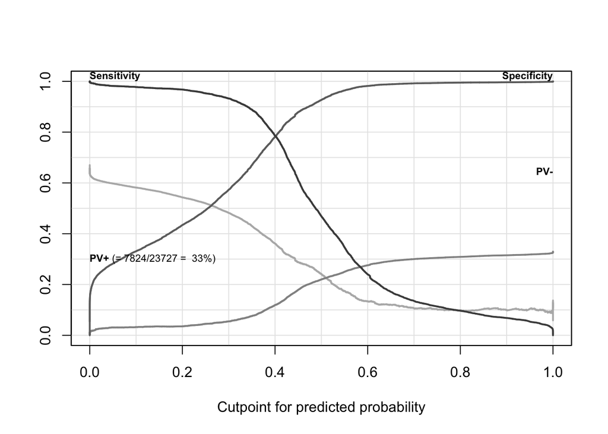

```r
ROC( form = Target ~ . , plot="sp" , data = train_data_Imputed_with_Stand_imp)
```

Observation:- 1. 0.4 or less looks to be the threshold based on sensitivity - specificity - cutoff graph

# Predict on training set

```r
target_pred = predict(model_aic_2,type=c("response"))
```

# ROC & AUC

```r
library(ROCR)
ROCRpred = prediction(target_pred, train_data_Imputed_with_Stand_imp$Target)
as.numeric(performance(ROCRpred, "auc")@y.values)
```

```
## [1] 0.8614191
```

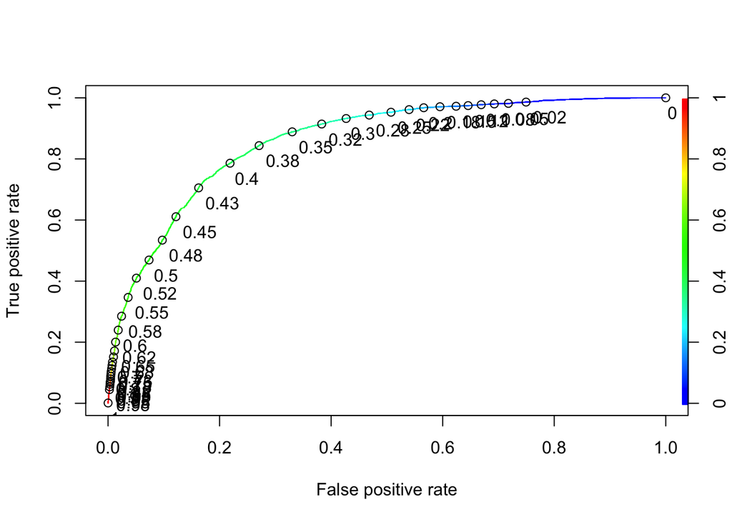

```r
ROCRperf <- performance(ROCRpred, "tpr", "fpr")
par(mfrow=c(1,1))
plot(ROCRperf, colorize = TRUE, print.cutoffs.at=seq(0,1,by=0.025), text.adj=c(-0.2,1.7))
```

```r
train_data_Imputed_with_Stand_imp$target_pred=target_pred
target_pred_round_num = ifelse(target_pred > 0.35, 1, 0)
#convert this to factor datatype
train_data_Imputed_with_Stand_imp$target_pred_round=as.factor(target_pred_round_num)
head(train_data_Imputed_with_Stand_imp)
```

```
##       A17.1      A19.1     A20.1          IV         A1        A2
## 1 -0.516442 -0.3910358  0.198099  3.77157266  0.3666650 0.1017770
## 3  1.936244 -0.3910358 -5.047767  0.39787947 -0.2295756 0.2693712
## 5 -0.516442 -0.3910358  0.198099 -0.21799982 -0.2579680 0.1017770
## 7 -0.516442 -0.3910358  0.198099 -0.20240794 -0.2153794 0.1017770
## 8 -0.516442 -0.3910358  0.198099 -0.17902012 -0.2579680 0.1017770
## 9 -0.516442 -0.3910358  0.198099  0.08993983  0.3524688 0.1017770
##            A3          A4         A14        A15        A12 Target
## 1  0.02134948 -0.08007735 -0.07945704 -0.9343976  0.2903552      0
## 3 -0.15895565 -0.08007735 -0.07945704  0.7183107 -0.2589895      0
## 5 -0.15895565 -0.08007735 -0.07945704  0.2461083 -0.2589895      0
## 7 -0.15895565 -0.08007735 -0.07945704  0.8757115 -0.2070697      0
## 8 -0.14256428 -0.08007735 -0.07945704  0.9150617 -0.1769227      0
## 9  0.05413223 -0.08007735 -0.07945704  0.9544119  0.1362707      0
##    target_pred target_pred_round
## 1 2.220446e-16                 0
## 3 3.323714e-08                 0
## 5 4.198291e-01                 1
## 7 3.408968e-01                 0
## 8 2.177967e-01                 0
## 9 6.892613e-04                 0
```

```r
confusionMatrix(train_data_Imputed_with_Stand_imp$target_pred_round, train_data_Imputed_with_Stand_imp$Target, positive = "1")
```

```
## Confusion Matrix and Statistics
##
##           Reference
## Prediction     0     1
##          0 10653   871
##          1  5250  6953
##
##                Accuracy : 0.742
##                  95% CI : (0.7364, 0.7476)
##     No Information Rate : 0.6702
##     P-Value [Acc > NIR] : < 2.2e-16
##
##                   Kappa : 0.489
##  Mcnemar's Test P-Value : < 2.2e-16
##
##             Sensitivity : 0.8887
##             Specificity : 0.6699
##          Pos Pred Value : 0.5698
##          Neg Pred Value : 0.9244
##              Prevalence : 0.3298
##          Detection Rate : 0.2930
##    Detection Prevalence : 0.5143
##       Balanced Accuracy : 0.7793
##
##        'Positive' Class : 1
##
```

" Observation:- 1. Sensitivity / Recall = 89 % . As we are looking for high Recall .35 threshold looks good. 2. 1 : Disease, 0 : Not Disease

## Test on validation_data

```r
head(validation_data)
```

```
##    A17.1 A19.1 A20.1  IV A1 A2 A3 A4 A5 A6 A7 A8 A9 A10 A12 A14  A15  A16
## 2      1     0     1  48  0  8  0  0  0  0  0  1  1   1   1   0 0.59 0.78
## 4      0     0     1  62  4  2  0  0  0 15 30  7 24  42  71   0 0.51 0.47
## 12     1     1     0 183  3 NA  0  0  0  0  0  3  5  11  21   0   NA   NA
## 20     1     0     1  13  1 12  2  0  0  0  0  0  0   0   0   0 0.48 0.48
## 21     0     0     1   3  6  8  0  0  6 10 15  1  6   9   9   0 0.79 0.66
## 22     1     0     1  11  0  2  0  0  0  0  0  0  0   0   0   0 0.18 0.33
##         A21 Target
## 2  17.02238      0
## 4  17.07500      0
## 12 17.08948      0
## 20 17.03576      0
## 21 17.04712      0
## 22 17.02201      0
```

```r
str(validation_data)
```

```
## 'data.frame':    10168 obs. of  20 variables:
##  $ A17.1 : num  1 0 1 1 0 1 1 0 0 0 ...
##  $ A19.1 : num  0 0 1 0 0 0 0 0 0 0 ...
##  $ A20.1 : num  1 1 0 1 1 1 1 1 1 1 ...
##  $ IV    : num  48 62 183 13 3 ...
##  $ A1    : num  0 4 3 1 6 0 0 70 0 188 ...
##  $ A2    : num  8 2 NA 12 8 2 2 2 9 16 ...
##  $ A3    : num  0 0 0 2 0 0 0 53 0 0 ...
##  $ A4    : num  0 0 0 0 0 0 0 0 0 0 ...
##  $ A5    : num  0 0 0 0 6 0 0 174 0 0 ...
##  $ A6    : num  0 15 0 0 10 0 0 398 0 0 ...
##  $ A7    : num  0 30 0 0 15 0 0 622 0 0 ...
##  $ A8    : num  1 7 3 0 1 0 0 53 0 139 ...
##  $ A9    : num  1 24 5 0 6 0 0 191 0 533 ...
##  $ A10   : num  1 42 11 0 9 0 0 350 0 959 ...
##  $ A12   : num  1 71 21 0 9 0 0 507 0 1400 ...
##  $ A14   : num  0 0 0 0 0 0 0 0 0 0 ...
##  $ A15   : num  0.59 0.51 NA 0.48 0.79 0.18 0.77 1 0.87 0.97 ...
##  $ A16   : num  0.78 0.47 NA 0.48 0.66 0.33 0.81 0.99 0.72 0.96 ...
##  $ A21   : num  17 17.1 17.1 17 17 ...
##  $ Target: Factor w/ 2 levels "0","1": 1 1 1 1 1 1 1 1 1 1 ...
```

```r
summary(validation_data)
```

```
##      A17.1            A19.1          A20.1             IV
##  Min.   :0.0000   Min.   :0.00   Min.   :0.000   Min.   :-591.0
##  1st Qu.:0.0000   1st Qu.:0.00   1st Qu.:1.000   1st Qu.:   2.0
##  Median :0.0000   Median :0.00   Median :1.000   Median :   7.0
##  Mean   :0.2091   Mean   :0.13   Mean   :0.965   Mean   : 109.1
##  3rd Qu.:0.0000   3rd Qu.:0.00   3rd Qu.:1.000   3rd Qu.:  36.0
##  Max.   :1.0000   Max.   :1.00   Max.   :1.000   Max.   :9879.0
##
##        A1                A2               A3                 A4
##  Min.   :   0.00   Min.   : 0.000   Min.   :   0.000   Min.   :  0.0000
##  1st Qu.:   0.00   1st Qu.: 2.000   1st Qu.:   0.000   1st Qu.:  0.0000
##  Median :   0.00   Median : 8.000   Median :   0.000   Median :  0.0000
##  Mean   :  17.95   Mean   : 7.336   Mean   :   9.535   Mean   :  0.9854
##  3rd Qu.:   3.00   3rd Qu.: 8.000   3rd Qu.:   0.000   3rd Qu.:  0.0000
##  Max.   :1532.00   Max.   :52.000   Max.   :1971.000   Max.   :591.0000
##                    NA's   :510
##        A5                A6               A7               A8
##  Min.   :   0.00   Min.   :   0.0   Min.   :   0.0   Min.   :  0.00
##  1st Qu.:   0.00   1st Qu.:   0.0   1st Qu.:   0.0   1st Qu.:  0.00
##  Median :   0.00   Median :   2.0   Median :   4.0   Median :  1.00
##  Mean   :  60.19   Mean   : 105.3   Mean   : 149.6   Mean   : 17.47
##  3rd Qu.:  17.00   3rd Qu.:  31.0   3rd Qu.:  45.0   3rd Qu.:  6.00
##  Max.   :3900.00   Max.   :6624.0   Max.   :9552.0   Max.   :967.00
##
##        A9               A10              A12              A14
##  Min.   :   0.00   Min.   :   0.0   Min.   :   0.0   Min.   :  0.000
##  1st Qu.:   0.00   1st Qu.:   0.0   1st Qu.:   0.0   1st Qu.:  0.000
##  Median :   3.00   Median :   5.0   Median :   8.0   Median :  0.000
##  Mean   :  53.12   Mean   : 100.6   Mean   : 152.1   Mean   :  1.098
##  3rd Qu.:  18.00   3rd Qu.:  34.0   3rd Qu.:  49.0   3rd Qu.:  0.000
##  Max.   :3712.00   Max.   :5626.0   Max.   :8941.0   Max.   :816.000
##
##       A15              A16              A21        Target
##  Min.   :0.0000   Min.   :0.0000   Min.   :17.00   0:6794
##  1st Qu.:0.6800   1st Qu.:0.6600   1st Qu.:17.03   1:3374
##  Median :0.8300   Median :0.8200   Median :17.05
##  Mean   :0.7576   Mean   :0.7536   Mean   :17.05
##  3rd Qu.:0.9600   3rd Qu.:0.9500   3rd Qu.:17.08
##  Max.   :1.0000   Max.   :1.0000   Max.   :17.10
##  NA's   :659      NA's   :627
```

# Impute Validation set data with imputedValues

```r
for(i in names(validation_data)){
  validation_data[is.na(validation_data[,i]), i] = as.numeric(imputedValues[i])
}


head(validation_data)
```

```
##    A17.1 A19.1 A20.1  IV A1 A2 A3 A4 A5 A6 A7 A8 A9 A10 A12 A14  A15  A16
## 2      1     0     1  48  0  8  0  0  0  0  0  1  1   1   1   0 0.59 0.78
## 4      0     0     1  62  4  2  0  0  0 15 30  7 24  42  71   0 0.51 0.47
## 12     1     1     0 183  3  8  0  0  0  0  0  3  5  11  21   0 0.82 0.81
## 20     1     0     1  13  1 12  2  0  0  0  0  0  0   0   0   0 0.48 0.48
## 21     0     0     1   3  6  8  0  0  6 10 15  1  6   9   9   0 0.79 0.66
## 22     1     0     1  11  0  2  0  0  0  0  0  0  0   0   0   0 0.18 0.33
##         A21 Target
## 2  17.02238      0
## 4  17.07500      0
## 12 17.08948      0
## 20 17.03576      0
## 21 17.04712      0
## 22 17.02201      0
```

```r
str(validation_data)
```

```
## 'data.frame':    10168 obs. of  20 variables:
##  $ A17.1 : num  1 0 1 1 0 1 1 0 0 0 ...
##  $ A19.1 : num  0 0 1 0 0 0 0 0 0 0 ...
##  $ A20.1 : num  1 1 0 1 1 1 1 1 1 1 ...
##  $ IV    : num  48 62 183 13 3 ...
##  $ A1    : num  0 4 3 1 6 0 0 70 0 188 ...
##  $ A2    : num  8 2 8 12 8 2 2 2 9 16 ...
##  $ A3    : num  0 0 0 2 0 0 0 53 0 0 ...
##  $ A4    : num  0 0 0 0 0 0 0 0 0 0 ...
##  $ A5    : num  0 0 0 0 6 0 0 174 0 0 ...
##  $ A6    : num  0 15 0 0 10 0 0 398 0 0 ...
##  $ A7    : num  0 30 0 0 15 0 0 622 0 0 ...
##  $ A8    : num  1 7 3 0 1 0 0 53 0 139 ...
##  $ A9    : num  1 24 5 0 6 0 0 191 0 533 ...
##  $ A10   : num  1 42 11 0 9 0 0 350 0 959 ...
##  $ A12   : num  1 71 21 0 9 0 0 507 0 1400 ...
##  $ A14   : num  0 0 0 0 0 0 0 0 0 0 ...
##  $ A15   : num  0.59 0.51 0.82 0.48 0.79 0.18 0.77 1 0.87 0.97 ...
##  $ A16   : num  0.78 0.47 0.81 0.48 0.66 0.33 0.81 0.99 0.72 0.96 ...
##  $ A21   : num  17 17.1 17.1 17 17 ...
##  $ Target: Factor w/ 2 levels "0","1": 1 1 1 1 1 1 1 1 1 1 ...
```

```r
summary(validation_data)
```

```
##      A17.1            A19.1          A20.1             IV
##  Min.   :0.0000   Min.   :0.00   Min.   :0.000   Min.   :-591.0
##  1st Qu.:0.0000   1st Qu.:0.00   1st Qu.:1.000   1st Qu.:   2.0
##  Median :0.0000   Median :0.00   Median :1.000   Median :   7.0
##  Mean   :0.2091   Mean   :0.13   Mean   :0.965   Mean   : 109.1
##  3rd Qu.:0.0000   3rd Qu.:0.00   3rd Qu.:1.000   3rd Qu.:  36.0
##  Max.   :1.0000   Max.   :1.00   Max.   :1.000   Max.   :9879.0
##        A1                A2               A3                 A4
##  Min.   :   0.00   Min.   : 0.000   Min.   :   0.000   Min.   :  0.0000
##  1st Qu.:   0.00   1st Qu.: 3.000   1st Qu.:   0.000   1st Qu.:  0.0000
##  Median :   0.00   Median : 8.000   Median :   0.000   Median :  0.0000
##  Mean   :  17.95   Mean   : 7.369   Mean   :   9.535   Mean   :  0.9854
##  3rd Qu.:   3.00   3rd Qu.: 8.000   3rd Qu.:   0.000   3rd Qu.:  0.0000
##  Max.   :1532.00   Max.   :52.000   Max.   :1971.000   Max.   :591.0000
##        A5                A6               A7               A8
##  Min.   :   0.00   Min.   :   0.0   Min.   :   0.0   Min.   :  0.00
##  1st Qu.:   0.00   1st Qu.:   0.0   1st Qu.:   0.0   1st Qu.:  0.00
##  Median :   0.00   Median :   2.0   Median :   4.0   Median :  1.00
##  Mean   :  60.19   Mean   : 105.3   Mean   : 149.6   Mean   : 17.47
##  3rd Qu.:  17.00   3rd Qu.:  31.0   3rd Qu.:  45.0   3rd Qu.:  6.00
##  Max.   :3900.00   Max.   :6624.0   Max.   :9552.0   Max.   :967.00
##        A9               A10              A12              A14
##  Min.   :   0.00   Min.   :   0.0   Min.   :   0.0   Min.   :  0.000
##  1st Qu.:   0.00   1st Qu.:   0.0   1st Qu.:   0.0   1st Qu.:  0.000
##  Median :   3.00   Median :   5.0   Median :   8.0   Median :  0.000
##  Mean   :  53.12   Mean   : 100.6   Mean   : 152.1   Mean   :  1.098
##  3rd Qu.:  18.00   3rd Qu.:  34.0   3rd Qu.:  49.0   3rd Qu.:  0.000
##  Max.   :3712.00   Max.   :5626.0   Max.   :8941.0   Max.   :816.000
##       A15              A16              A21        Target
##  Min.   :0.0000   Min.   :0.0000   Min.   :17.00   0:6794
##  1st Qu.:0.6800   1st Qu.:0.6800   1st Qu.:17.03   1:3374
##  Median :0.8200   Median :0.8100   Median :17.05
##  Mean   :0.7616   Mean   :0.7571   Mean   :17.05
##  3rd Qu.:0.9600   3rd Qu.:0.9500   3rd Qu.:17.08
##  Max.   :1.0000   Max.   :1.0000   Max.   :17.10
```